# ExpHunterSuite: All Clusters Report

SysBioLab

## **MF Over Representation Analysis**

The ORA method takes a group of significative DEGs (only DEGs, upregulated DEGs or downregulated DEGs) and performs a hypergeometric test for each term of the selected functional category.

| Cluster | ID | Description | GeneRatio | BgRatio | p.adjust | geneID | Count |
| --- | --- | --- | --- | --- | --- | --- | --- |
| mmu-miR-155-5p | GO:1904315 | transmitter-gated ion channel activity involved in regulation of postsynaptic membrane potential | 0.0352941176470588 | 42/13204 | 0.00211710293943053 | Gria3/Gabrg2/Grik1/Gria4/Glrb/Gria2 | 6 |
| mmu-miR-155-5p | GO:0004970 | ionotropic glutamate receptor activity | 0.0235294117647059 | 17/13204 | 0.0034860898960588 | Gria3/Grik1/Gria4/Gria2 | 4 |
| mmu-miR-155-5p | GO:0099094 | ligand-gated cation channel activity | 0.0294117647058824 | 72/13204 | 0.0733300867191537 | Gria3/Grik1/Gria4/Gria2/Ryr3 | 5 |
| mmu-miR-155-5p | GO:0005231 | excitatory extracellular ligand-gated ion channel activity | 0.0176470588235294 | 22/13204 | 0.0784240875070297 | Grik1/Glrb/Gria2 | 3 |
| mmu-miR-155-5p | GO:0003729 | mRNA binding | 0.0588235294117647 | 276/13204 | 0.0826332722433538 | Celf2/Rbm25/Fyttd1/Hnrnpll/Ncl/Dhx36/Ptbp2/Luc7l2/Zc3h12b/Tardbp | 10 |

**Dotplot**

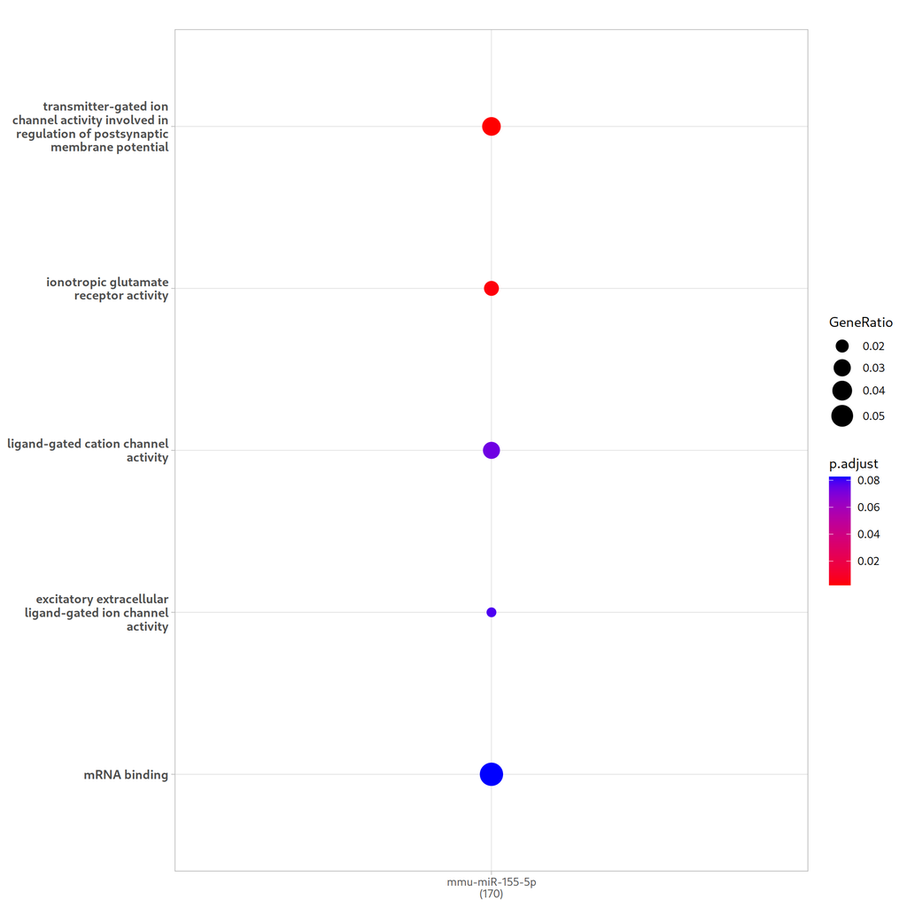

**Heatplot**

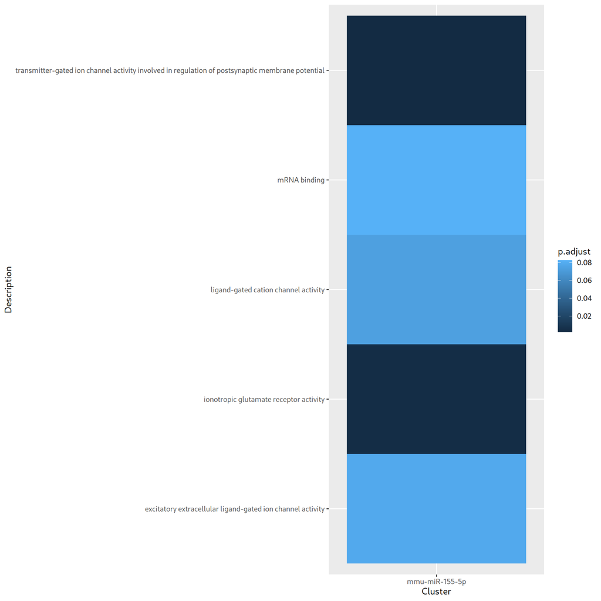

**Gene-Concept Network**

The network connects the top functional categories (brown nodes) to their associated genes (grey or colored nodes). The size of the functional category nodes shows the number of connected genes.

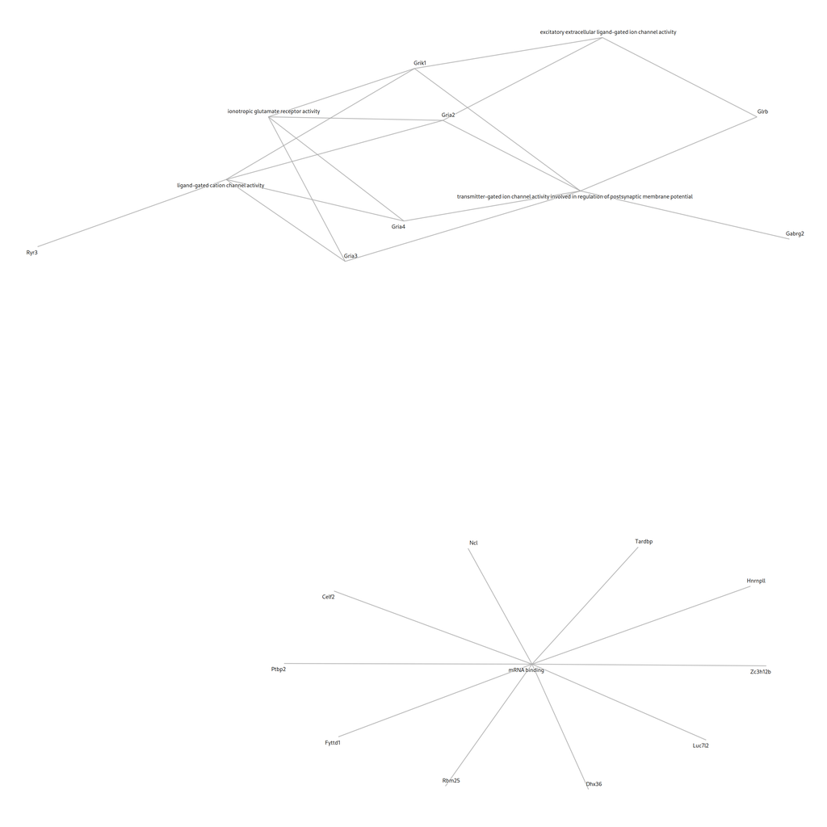

**Enrich Map plot**

The top functional categories (nodes), connected if they share genes. Edge thickness represents the number of shared genes. Nodes size represents the number of significant genes within the category. Pies proportion represent the proportion of genes belonging to each cluster.

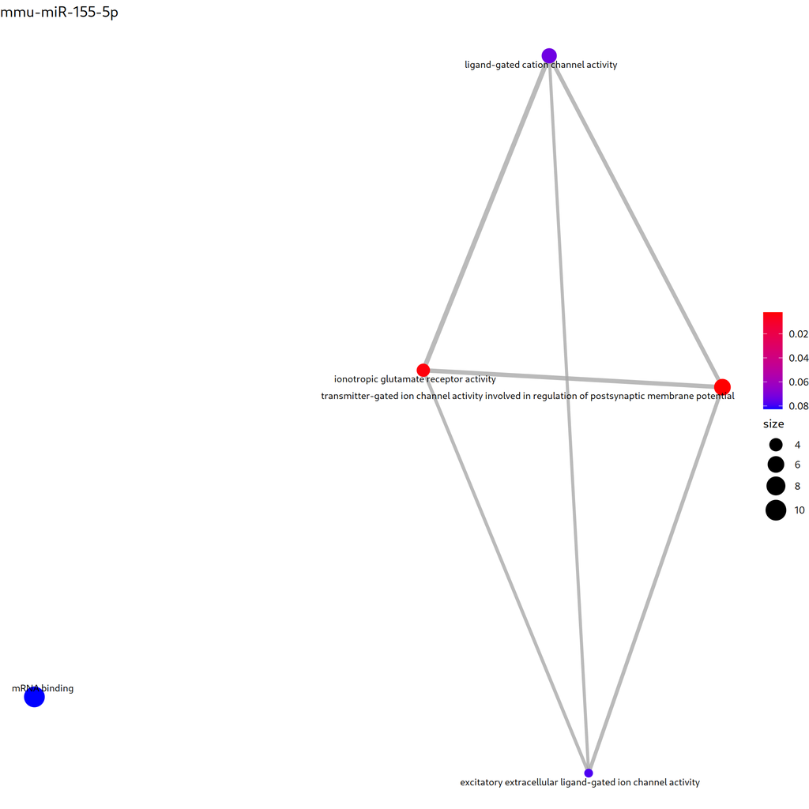

**Cluster concept network plot**

The top functional categories (nodes), connected if they are shared among clusters. Edge thickness represents the number of shared genes. Nodes size represents the number of clusters sharing the functional category. Pies proportion represent the proportion of clusters with that enriched category.

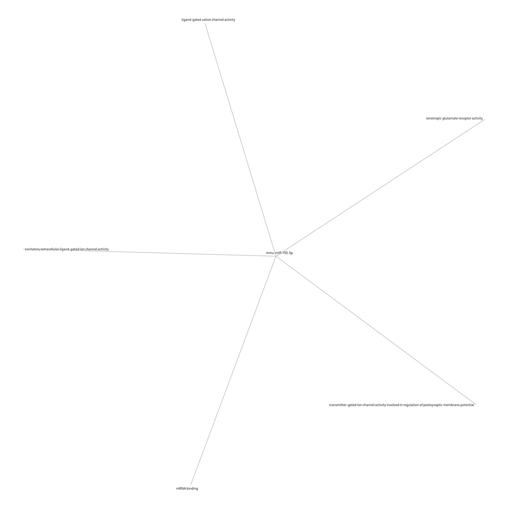

## **BP Over Representation Analysis**

The ORA method takes a group of significative DEGs (only DEGs, upregulated DEGs or downregulated DEGs) and performs a hypergeometric test for each term of the selected functional category.

| Cluster | ID | Description | GeneRatio | BgRatio | p.adjust | geneID | Count |
| --- | --- | --- | --- | --- | --- | --- | --- |
| mmu-miR-142a-5p | GO:0007626 | locomotory behavior | 0.0854700854700855 | 232/13343 | 0.0786828251577745 | Agtpbp1/Fgf14/Snap25/Oprl1/Elavl4/Mtor/Adam22/Cntn1/Kcnd2/Scn1a | 10 |
| mmu-miR-142a-5p | GO:0009112 | nucleobase metabolic process | 0.0341880341880342 | 26/13343 | 0.0786828251577745 | Mtor/Prps1/Gda/Mapk1 | 4 |

**Dotplot**

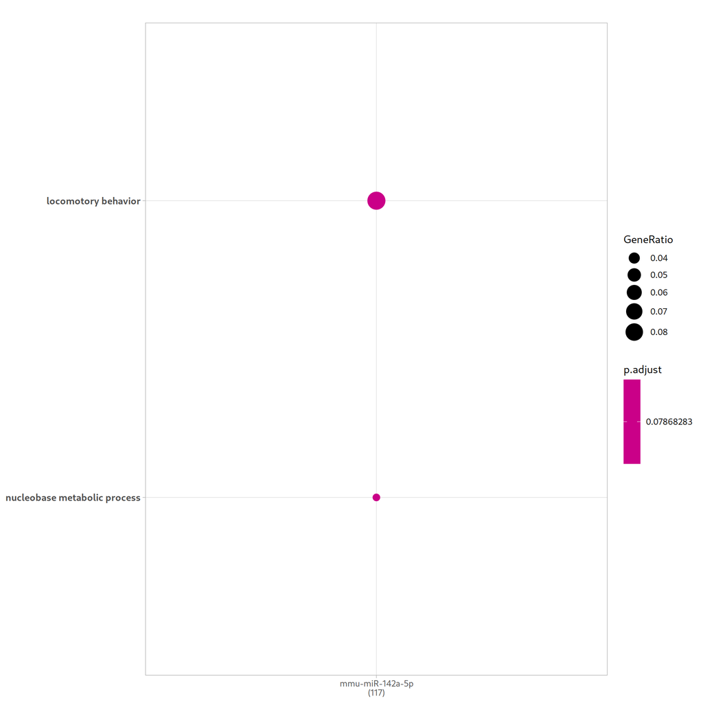

**Heatplot**

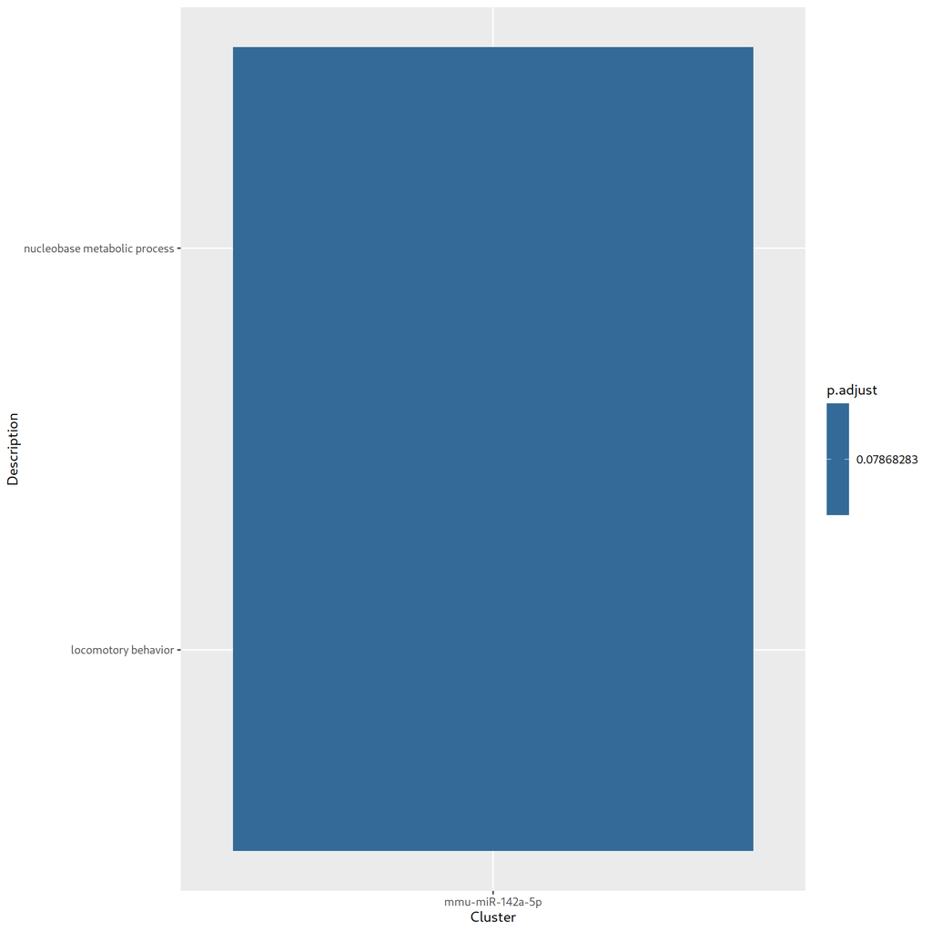

**Gene-Concept Network**

The network connects the top functional categories (brown nodes) to their associated genes (grey or colored nodes). The size of the functional category nodes shows the number of connected genes.

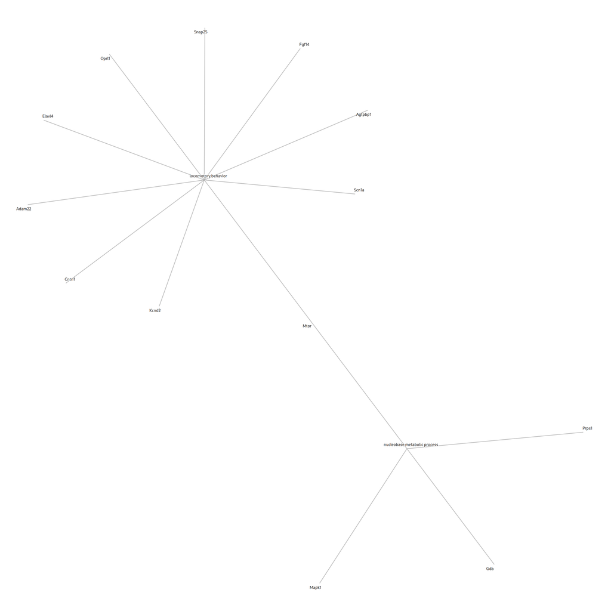

**Cluster concept network plot**

The top functional categories (nodes), connected if they are shared among clusters. Edge thickness represents the number of shared genes. Nodes size represents the number of clusters sharing the functional category. Pies proportion represent the proportion of clusters with that enriched category.

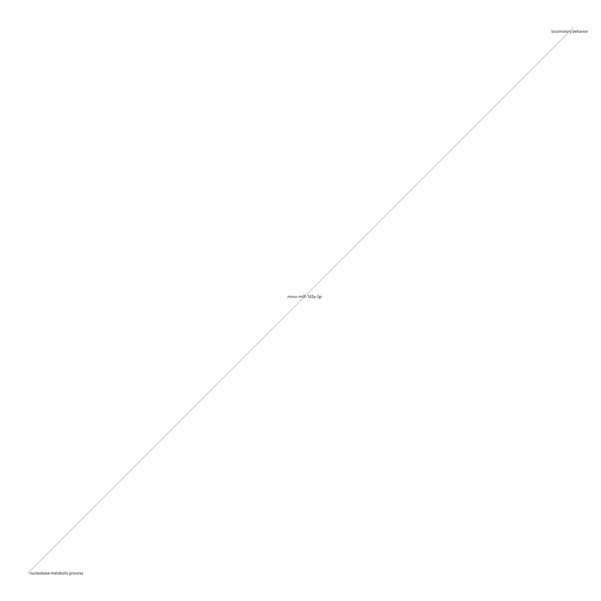

## **CC Over Representation Analysis**

The ORA method takes a group of significative DEGs (only DEGs, upregulated DEGs or downregulated DEGs) and performs a hypergeometric test for each term of the selected functional category.

| Cluster | ID | Description | GeneRatio | BgRatio | p.adjust | geneID | Count |
| --- | --- | --- | --- | --- | --- | --- | --- |
| mmu-miR-142a-5p | GO:0034702 | ion channel complex | 0.076271186440678 | 226/13422 | 0.0374265288022709 | Stxbp5/Gabrg2/Pde4d/Snap25/Gabrb3/Akap9/Unc80/Kcnd2/Scn1a | 9 |
| mmu-miR-142a-5p | GO:0097060 | synaptic membrane | 0.0932203389830508 | 358/13422 | 0.0374265288022709 | Gabrg2/Snap25/Epha7/Ptprd/Cadm1/Gabrb3/Akap9/Adam22/Cltc/Cntn1/Kcnd2 | 11 |
| mmu-miR-142a-5p | GO:0098978 | glutamatergic synapse | 0.076271186440678 | 312/13422 | 0.0984196721211809 | Snap25/Napb/Tnik/Epha7/Ptprd/Cadm1/Akap9/Adam22/Kcnd2 | 9 |
| mmu-miR-146a-5p | GO:0043204 | perikaryon | 0.108108108108108 | 122/13422 | 0.0483203645690889 | Gria3/Itga8/Dhx36/Kcnab1 | 4 |

**Dotplot**

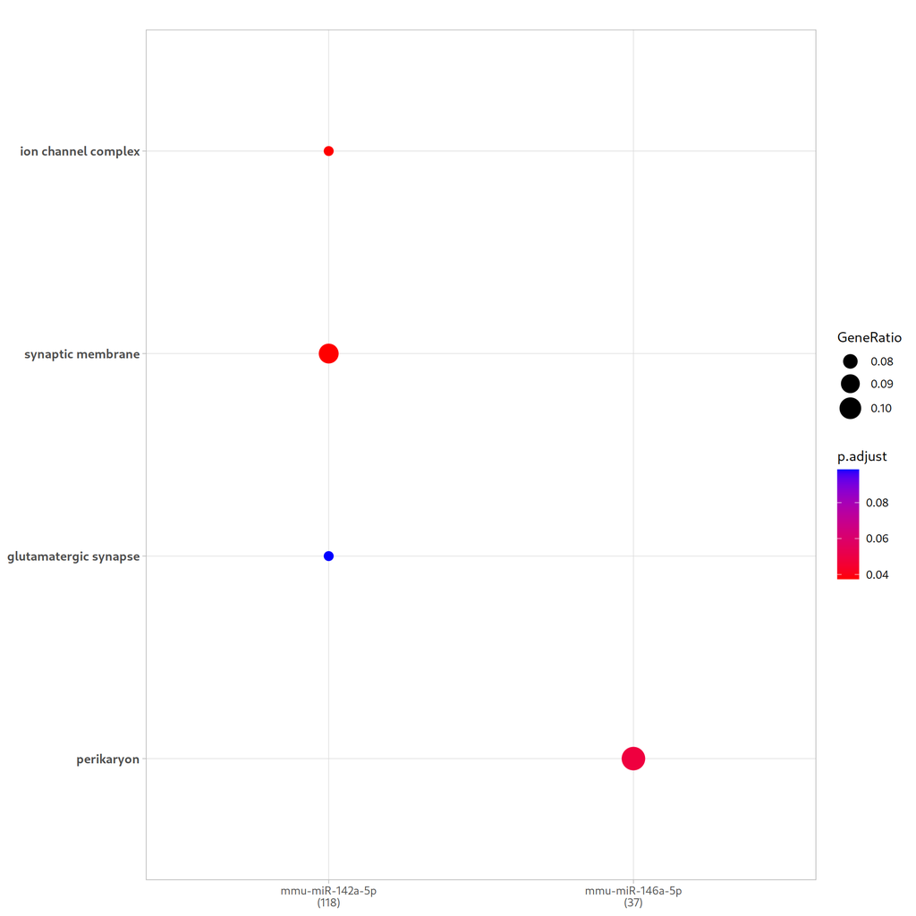

**Heatplot**

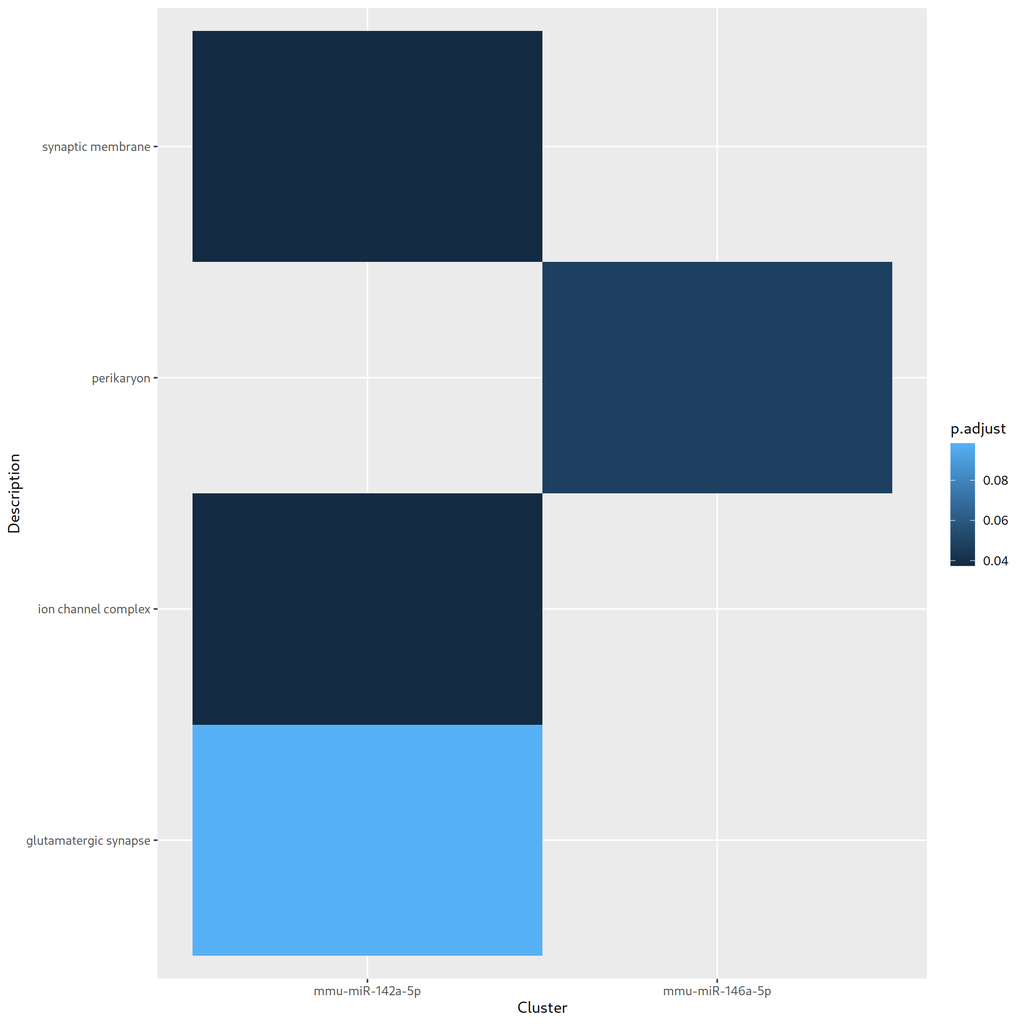

**Gene-Concept Network**

The network connects the top functional categories (brown nodes) to their associated genes (grey or colored nodes). The size of the functional category nodes shows the number of connected genes.

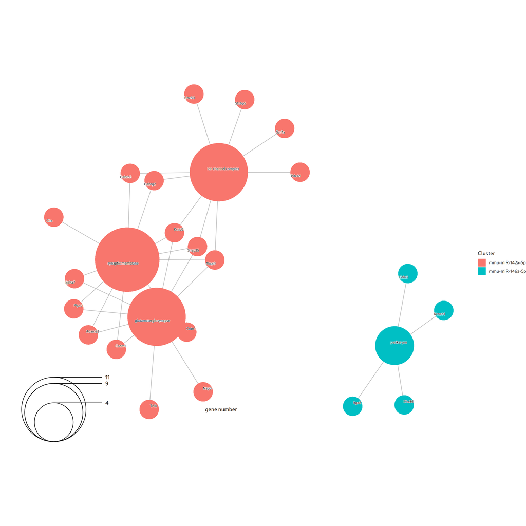

**Enrich Map plot**

The top functional categories (nodes), connected if they share genes. Edge thickness represents the number of shared genes. Nodes size represents the number of significant genes within the category. Pies proportion represent the proportion of genes belonging to each cluster.

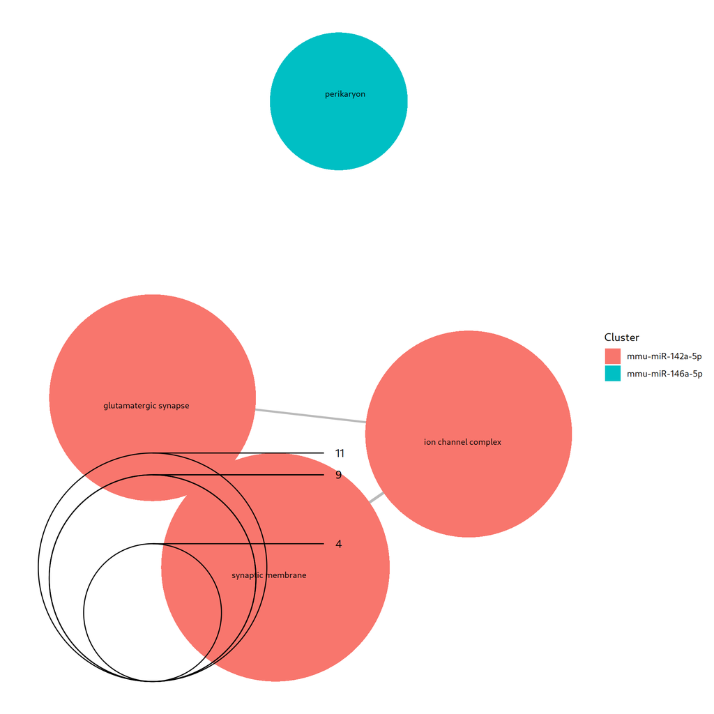

**Cluster concept network plot**

The top functional categories (nodes), connected if they are shared among clusters. Edge thickness represents the number of shared genes. Nodes size represents the number of clusters sharing the functional category. Pies proportion represent the proportion of clusters with that enriched category.

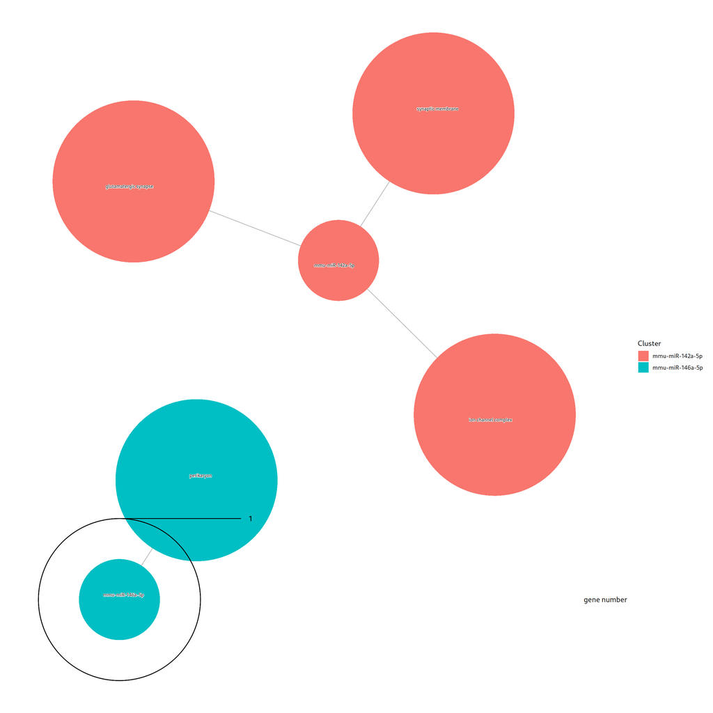

## **KEGG Over Representation Analysis**

The ORA method takes a group of significative DEGs (only DEGs, upregulated DEGs or downregulated DEGs) and performs a hypergeometric test for each term of the selected functional category.

| Cluster | ID | Description | GeneRatio | BgRatio | p.adjust | geneID | Count |
| --- | --- | --- | --- | --- | --- | --- | --- |
| mmu-miR-155-5p | mmu04713 | Circadian entrainment | 0.0909090909090909 | 87/5646 | 0.0611296531780363 | Gria3/Gria4/Gucy1b1/Gria2/Ryr3/Mapk1 | 6 |
| mmu-miR-155-5p | mmu05033 | Nicotine addiction | 0.0606060606060606 | 35/5646 | 0.0611296531780363 | Gria3/Gabrg2/Gria4/Gria2 | 4 |

**Dotplot**

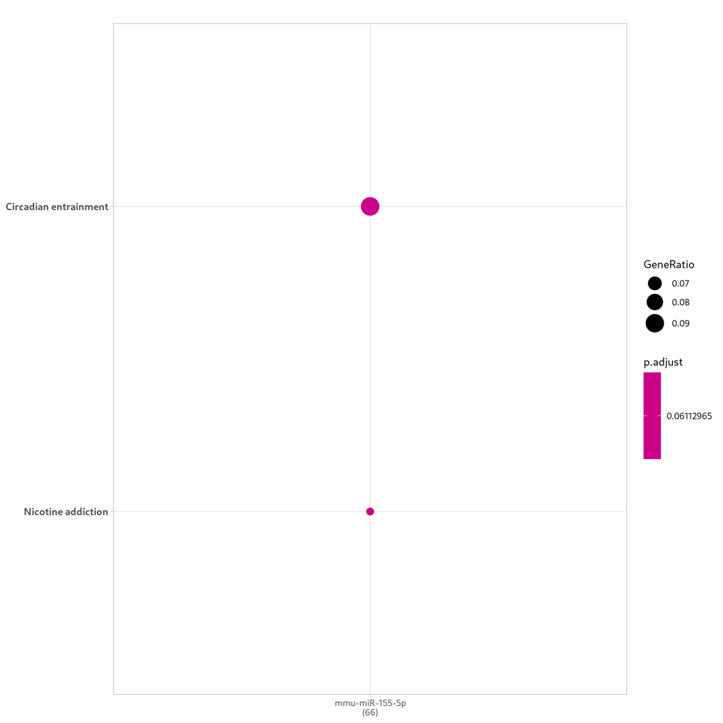

**Heatplot**

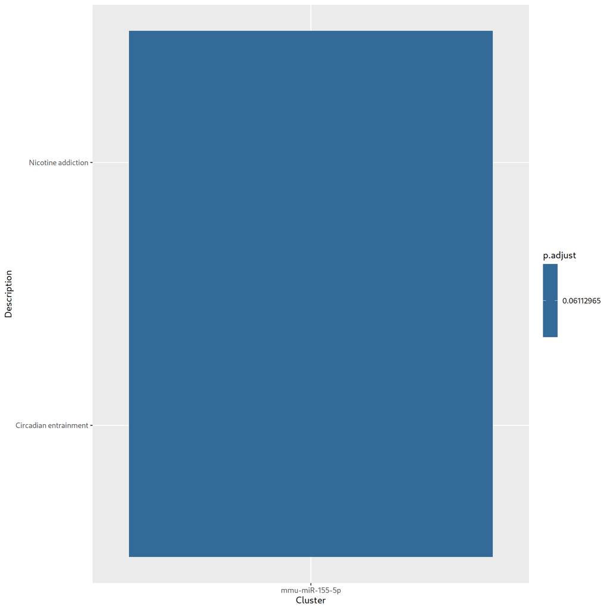

**Gene-Concept Network**

The network connects the top functional categories (brown nodes) to their associated genes (grey or colored nodes). The size of the functional category nodes shows the number of connected genes.

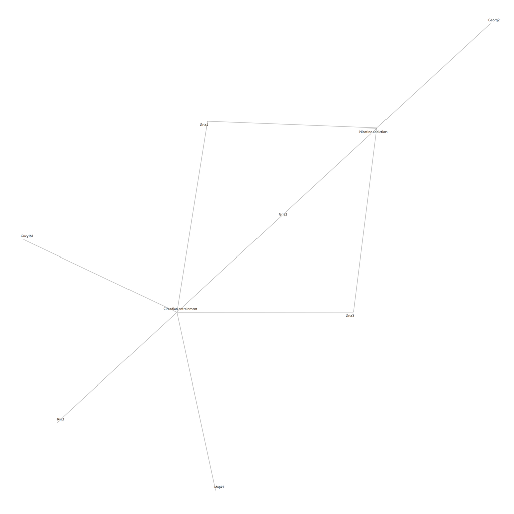

**Cluster concept network plot**

The top functional categories (nodes), connected if they are shared among clusters. Edge thickness represents the number of shared genes. Nodes size represents the number of clusters sharing the functional category. Pies proportion represent the proportion of clusters with that enriched category.

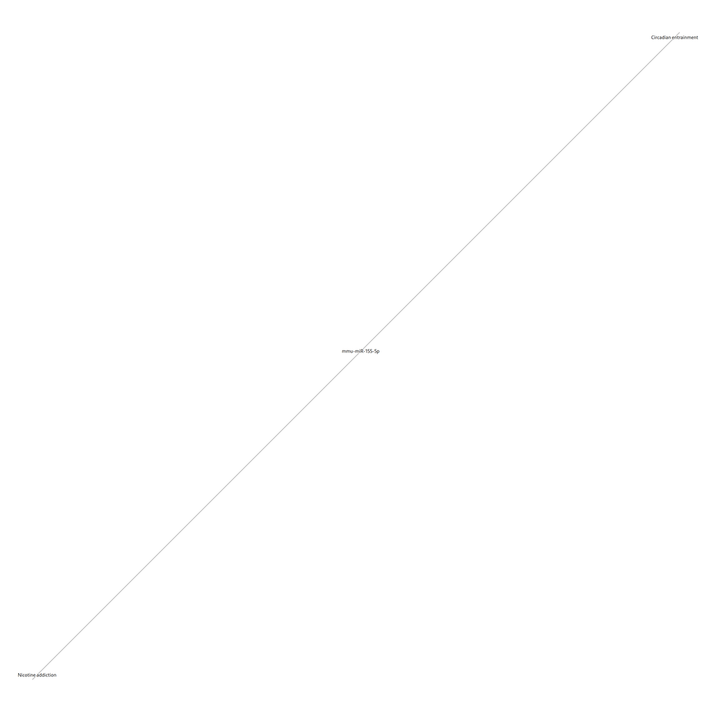

## **No enrichment found for Reactome**